# Astrarium（アストラリウム）— 星図とプラネタリウム

[figure not shown]

# Astrarium（アストラリウム）

**星図とプラネタリウム — 観測地と日時を決めれば、その空をそのまま描きます**

iPhone・iPad・Mac・Apple Watch 対応（Android 版はテスト公開中）／無料／広告なし・アカウント登録なし （Astrarium Pro は、同じアプリの中の任意の購読です）

### [📲 App Store で入手する](https://apps.apple.com/jp/app/id6795053748)

[figure not shown]

日本語 ・ English

## 画面

[figure not shown]

[figure not shown]

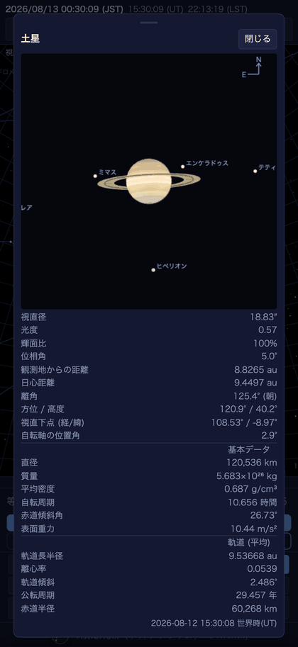

[figure not shown]

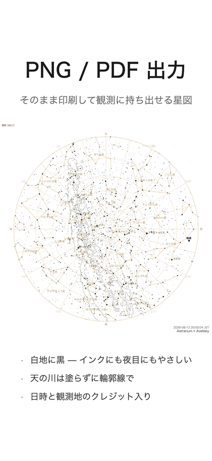

[figure not shown]

[figure not shown]

[figure not shown]

## できること

- **全天モードと地平モード** — 星座早見盤と同じ丸い全天図と、実際に空を見上げたときに近い地平図
- **時刻を自由に動かす** — 任意の日時へジャンプ、1 倍から 6000 倍までの段階再生、朔望月送り、時刻を完全に止める停止ボタン
- **天体をタップすれば、その場の数値** — 方位・高度・座標・距離・出没時刻が、時計を動かすとそのまま追従します
- **惑星の拡大表示** — 視直径・輝面比・距離・軌道要素、基本物理量（直径・質量・密度・自転周期・赤道傾斜角・表面重力）、木星／土星／火星の衛星の配置
- **月** — 月齢・輝面比・秤動・欠け際、満月の呼称（ピンクムーン、スーパームーンなど）
- **極軸合わせ** — 北極星を選ぶと極軸望遠鏡の視野を再現。時角の目盛環の上で、いま北極星をどこに入れるかが分かります
- **流星群カレンダー** — 極大日時、輻射点高度、月明かりを織り込んだ予想出現数
- **彗星・小惑星** — 彗星 4,122 個の軌道要素を内蔵（MPC と JPL SBDB の合わせ技）。MPC／JPL から取り直すこともできます
- **イベント一覧** — 天体イベント全般のほか、掩蔽・恒星食、日食・月食を選んで一覧。後の二つは**その観測地から実際に見えるものだけ**を示します
- **4 種の経緯線**、天の赤道・黄道・銀河面・子午線、写野角枠（Seestar・DWARF・カメラレンズ）
- **ナイトモード**（赤色画面）、**長時間露光**、**PNG／PDF 出力**（白背景の印刷用配色）、字幕つきデモ再生
- **日本語と英語** — 天体名・星座名・星雲星団の解説まで、どちらでも読めます（恒星の固有名は日本語ではカタカナ表記）

## 収録データ（すべて内蔵・オフラインで動作）

| 内容 | 出典 |
| --- | --- |
| 恒星 9,096 個（約 8 等まで、距離つき） | Yale Bright Star Catalogue (BSC5) ／ 視差は Hipparcos |
| 星雲・星団・銀河 155 個（写真と解説つき） | メシエ天体／カルドウェル天体 |
| IAU 88 星座の星座線 672 本と星座絵 | — |
| 天の川の全天マップ | NASA Deep Star Maps 2020（Gaia DR2 ほか17億星の光を積算） |
| 惑星・月の暦と表面テクスチャ | JPL DE421 |
| 彗星 4,122 個の軌道要素 | MPC CometEls ／ JPL SBDB |
| 主要流星群 16 件、MPC 観測所コード、世界の観測地 | — |

天体の位置計算はすべて端末の中で行います。電波の届かない観測地でも全機能がそのまま使えます。

## Astrarium Pro

**Astrarium Pro** は、同じアプリの中の任意の購読です（2.1 から。それまでは 別売のアプリでした）。入口は施錠された状態で同じ場所にあり、押すと何が増えるのかと 値段が出ます。月額 400 円 / 年額 4,000 円（日本の場合。価格は国・地域により 異なります）、最初の 1 週間は無料です。

**AR は購読しなくても使えます。** 人工衛星も、宇宙ステーション（ISS・天宮）と 肉眼で見える衛星（4 等まで）までは課金の外にあります。

[figure not shown]

[figure not shown]

[figure not shown]

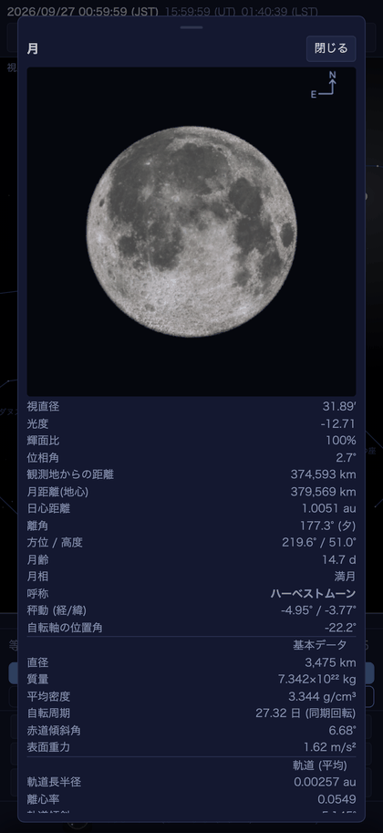

- **太陽系3Dマップ** — 小惑星 156 万個・彗星 4,122 個・準惑星を、黄道面の上から。 探査機 35 機は**実際に飛んだ道を同梱**しているので（37 万点）、通信の無い 場所でもボイジャーの軌跡がそのまま出ます
- **オーロラ予報** — NASA DONKI と NOAA OVATION から、オーロラ帯がどこまで下がるか、 観測地から見て地平線の上に出るかを描きます。色は輝線（酸素 557.7 / 630.0 nm、 窒素）の強さを高さごとに解いて CIE の等色関数で画面の色に直し、カーテンは 磁力線に沿わせています。**オーロラ爆発**（サブストーム）も再現します — 真夜中手前の弧が崩れ、極へ膨らみながら西へ走り、回復相で脈動へ変わるまで
- **固有運動タイムマシン** — ±5 万年。星が動き、星座の形が崩れ、北極星が入れ替わります
- **深宇宙星表** — UCAC4 の 234 万星（12 等まで）。視野 12 度以下で降りてきます。 本体は 37 MB あるのでアプリには積まず、**使う人だけが落とす**形にしました （探索タブの一番下から。一度落とせば端末に残り、次からは通信しません）
- **人工衛星の残りの群**（Starlink・気象衛星・科学衛星・日本の静止衛星ほか）と、 世界地図・地球儀での表示、名前と ID での検索
- **系外惑星のトランジット予報・変光星の極大と極小**
- **等距離射影**（ドームマスター）と**地方恒星時**

## Apple Watch

iPhone に入れると、**Apple Watch にも入ります**（別に買うものはありません）。

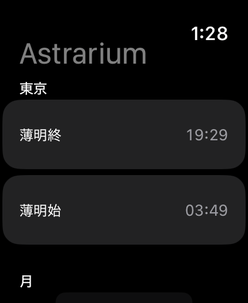

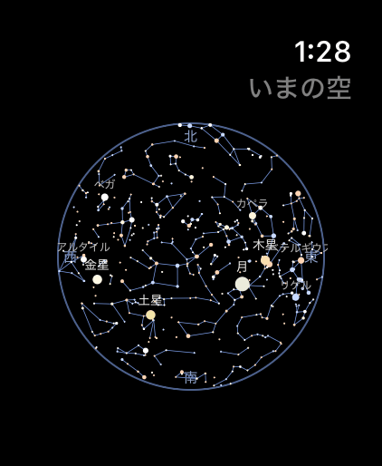

腕の上で読みたいのは、これから数時間の空であって星表ではない — そう考えて、二つだけ置いています。

- **今夜** — 薄明の終わりと始まり、月齢と月の出入り、いま出ている惑星の方角と高度、次の人工衛星の通過、活動中の流星群
- **星図** — 全天を一枚の円に（等距離射影）。デジタルクラウンで前後 12 時間まで送れます。画面を叩くと星の名前が消えます

恒星と星座線は時計の中で計算します（986 個の星表を積んでいます）。太陽・月・惑星と人工衛星は iPhone が計算して送ります。**数字がいつのものかを画面の下に出し**、iPhone と離れているあいだはそう書きます。一度届いたあとは、iPhone が鞄の中でも星図は時計だけで動きます。

## Android 版

Android 版ができました。**いまは公開前のクローズドテスト中**で、参加してくださる方を募集しています。

星図・計算・画面は iPhone / iPad 版とまったく同じものを積んでいるので、同じ空を同じ精度で描きます。Android 版で違うのは次の四つです。

- **AR で北を手で合わせる必要がありません** — 端末の絶対方位センサから真北がそのまま得られます
- **AR と宇宙ステーション**（ISS・天宮）**の通過予報が最初から使えます**（Apple 版も同じで、どちらも購読は要りません。Starlink を含む残りの群は Apple 版では購読の内側です）
- **書き出したものは共有フォルダに入ります** — PNG は `Pictures/Astrarium`、PDF は `ダウンロード/Astrarium`。アプリを削除しても残ります
- 位置情報の許可は初回の起動時に尋ねます。断っても全機能が使えます

### テストに参加するには

参加は二段階で、**両方**必要です。

1. Google グループ astrarium に参加する
2. そのうえで Play でテスターに登録する（登録用のリンクはグループに掲示しています）

①を飛ばして②を開くと「App not available」と出ます。**アプリが未公開なのではなく**、いま開いているアカウントがグループの一員として Play 側にまだ届いていない、という意味です。少し時間を置いてから開き直してください。

Google の公開要件で、テスターは **14 日間続けて**参加している必要があります。途中で抜けると数え直しになってしまうので、それまでは登録したままにしていただけると助かります。

**アプリ自体は、いつ消していただいても構いません。** カウントから外れるのは、登録に使ったリンクの画面で「テストを終了」を押したときだけで、アンインストールでは外れません。ただ、**一度だけ起動して触ってみて**いただけると助かります（実際に使われたかどうかも見られているためです）。

## 動作環境

| iPhone / iPad | iOS・iPadOS 17.0 以降 |
| --- | --- |
| Android | Android 8.0 以降（クローズドテスト中） |
| Mac | macOS 13.0 以降（Apple シリコン・Intel） |
| Apple Watch | watchOS 10.0 以降。iPhone 版に同梱しています |
| 価格 | 無料。iPhone / iPad と Mac はユニバーサル購入（片方で入手すれば両方で使えます） |

## 使用マニュアル

|  | 日本語 | English |
| --- | --- | --- |
| iPhone / iPad 版 | PDF | PDF |
| Android 版 | PDF | PDF |
| Mac 版 | PDF | PDF |
| Astrarium Pro | PDF | PDF |

画面の見かた、操作、流星群の出現数の計算、極軸合わせ、PNG／PDF 出力まで、実機の画面を添えて説明しています。Android 版は画面が iPhone / iPad 版と同じなので本文もほぼ共通で、違うところ（書き出しの行き先、AR、位置情報の許可）だけが差し替えてあります。Mac 版は右パネルの構成とマウス・トラックパッドの操作に合わせた別冊です。Apple Watch は iPhone / iPad 版マニュアルの第 12 章です。Pro のマニュアルには、太陽系3Dマップ・オーロラ予報・固有運動タイムマシン・深宇宙星表の章が加わります。

## プライバシー

現在地は「その場所の空」を計算するためだけに使い、端末の外へは一切送信しません。許可しなくても、観測地の一覧から選ぶか緯度・経度を入力すれば、すべての機能を同じように使えます。解析や広告の SDK は含まれていません。

プライバシーポリシー（日本語） ・ Privacy policy (English)

## サポート

不具合のご連絡・ご質問は avellsky@gmail.com までお願いします。お使いの機種・OS のバージョン・再現手順を添えていただけると助かります。返信までに数日いただく場合があります。

# Astrarium

**A planisphere and astronomical simulator — choose a place and a time, and it draws that sky.**

For iPhone, iPad, Mac and Apple Watch; an Android version is in closed testing. Free, with no ads and no account. Astrarium Pro is an optional subscription inside the same app.

### [📲 Get it on the App Store](https://apps.apple.com/jp/app/id6795053748)

## What it does

- **All-sky and horizon views** — the whole sky as a circle, as on a cardboard planisphere, or the sky as you would actually see it looking out
- **Drive the clock** — jump to any date, step the rate ×1 → ×60 → ×600 → ×6000, advance by the synodic month, or hold the sky still
- **Tap anything and the figures follow the clock** — azimuth, altitude, coordinates, distance, and the times it rises and sets
- **Planet close-ups** — apparent diameter, phase, distances, orbital elements, the physical data (diameter, mass, density, rotation, axial tilt, gravity) and the moons of Jupiter, Saturn and Mars
- **The Moon** — age, illuminated fraction, libration, terminator and the traditional full-moon names
- **Polar alignment** — select Polaris and the polar scope’s field is drawn, with an hour-angle ring showing where Polaris must sit right now
- **Meteor shower calendar** — maximum, radiant altitude and an expected hourly rate that accounts for moonlight and twilight
- **Comets and asteroids** — 4,122 comets bundled (MPC CometEls together with JPL’s SBDB), and the elements can be fetched again from the MPC and JPL
- **Events** — all astronomical events, or occultations and eclipses on their own; those two list only what can actually be seen from your site
- **Four coordinate grids**, the celestial equator, ecliptic, galactic plane and meridian, and field-of-view frames
- **Night-vision mode**, **long exposure**, **PNG/PDF export** on white paper, and a captioned demo tour
- **Japanese and English throughout** — object names, constellations and the deep-sky descriptions

## Catalogues (all bundled — it works offline)

| Contents | Source |
| --- | --- |
| 9,096 stars to about magnitude 8, with distances | Yale Bright Star Catalogue (BSC5); parallaxes from Hipparcos |
| 155 nebulae, clusters and galaxies, with photographs | Messier and Caldwell |
| The 88 IAU constellations: 672 line segments and the figures | — |
| A whole-sky Milky Way map | NASA Deep Star Maps 2020 — the light of 1.7 billion stars |
| Planetary and lunar ephemeris with surface maps | JPL DE421 |
| Orbital elements for 4,122 comets | MPC CometEls and JPL SBDB |
| 16 major meteor showers, MPC observatory codes, observing sites | — |

Every position is computed on the device, so the whole app works where there is no signal.

## Astrarium Pro

**Astrarium Pro** is an optional subscription inside the same app (since 2.1; before that it was a separate app). The entry points stay where they are, locked, and show what they add and what it costs. US$3.99 a month or US$39.99 a year (United States; prices vary by region), with the first week free.

**AR needs no subscription**, and neither do the space stations (ISS and Tiangong) or the naked-eye satellites down to magnitude 4.

[figure not shown]

[figure not shown]

[figure not shown]

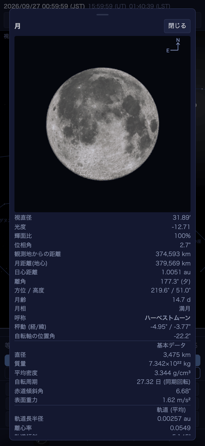

- **3D solar system map** — 1.56 million minor planets, 4,122 comets and the dwarf planets, seen from above the ecliptic. The paths 35 spacecraft actually flew are **carried in the app** (370,000 points), so Voyager’s track is drawn where there is no signal
- **Aurora forecast** — from NASA DONKI and NOAA OVATION: how far the auroral oval reaches, and whether it clears the horizon where you are. The colour is computed from the emission lines themselves (oxygen 557.7 / 630.0 nm, nitrogen) at each altitude and converted through the CIE colour matching functions; the curtains follow the magnetic field lines. An **auroral breakup** plays out too — the arc before midnight falling apart, swelling poleward, running west, and turning into pulsating patches
- **Proper-motion time machine** — 50,000 years either way; the figures come apart and the pole star changes
- **Deep-sky star catalogue** — 2.34 million UCAC4 stars to 12th magnitude, appearing below a 12-degree field. At 37 MB it is not carried in the app: **whoever wants it downloads it** (from the foot of the Explore tab). Once downloaded it stays on the device and needs no connection afterwards
- **The remaining satellite groups** (Starlink, weather, science, the Japanese geostationary ones) with a world map, a globe and search by name or ID
- **Exoplanet transits and variable-star maxima and minima**
- **The equidistant (dome master) projection** and **local sidereal time**

## Apple Watch

Install it on iPhone and it **goes to the Apple Watch with it** — there is nothing more to buy.

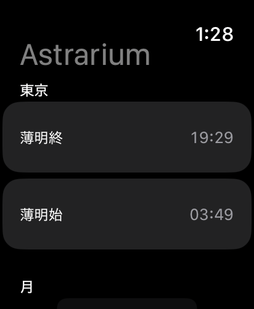

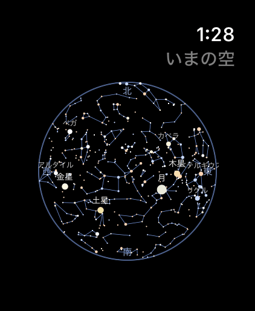

What you want on your wrist is the next few hours of sky, not a catalogue, so there are only two screens.

- **Tonight** — when it gets dark and light again, the Moon’s age and rise and set, which planets are up and where, the next satellite pass, and any shower running
- **Star chart** — the whole sky in one disc (equidistant projection). Turn the Digital Crown to move up to twelve hours either way; tap to hide the star names

Stars and constellation lines are computed on the watch itself (986 of them are carried there). The Sun, Moon, planets and satellites are solved on the iPhone and sent across. **The bottom line says how old the figures are**, and says so plainly while the iPhone is out of range. After that first delivery the chart keeps working on the watch alone.

## Android

An Android version is ready and is **in closed testing** before release; testers are welcome. It bundles the same chart, the same computing core and the same screen as the iPhone and iPad version, so it draws the same sky to the same accuracy. Four things differ:

- **AR needs no manual alignment to north** — true north comes straight from the device’s absolute-orientation sensor
- **AR and the space stations** (ISS and Tiangong) **are included** — the same on Apple, where neither needs a subscription (the remaining groups, Starlink included, are inside Astrarium Pro there)
- **What you export lands in shared folders** — PNG in `Pictures/Astrarium`, PDF in `Download/Astrarium`. They remain after the app is removed
- Location permission is asked for on first launch; decline it and nothing is lost

### Joining the test

There are two steps, and **both** are needed:

1. Join the Google group astrarium
2. Then opt in as a tester on Play (the link is posted in the group)

If you open step 2 first, Play answers “App not available”. **The test is not closed** — it means the account you are signed in with has not reached Play as a member of the group yet. Wait a little and open it again.

Google requires testers to stay opted in for **14 consecutive days**, so please leave it in place until then.

**Uninstalling the app is fine at any point.** The only thing that drops you from the count is pressing “Leave the test” on the link you signed up with. Do open it once, though — Google also looks at whether testers actually used the app.

## Requirements

| iPhone / iPad | iOS and iPadOS 17.0 or later |
| --- | --- |
| Android | Android 8.0 or later (in closed testing) |
| Mac | macOS 13.0 or later (Apple silicon and Intel) |
| Apple Watch | watchOS 10.0 or later — it ships inside the iPhone app |
| Price | Free. iPhone / iPad and Mac are a universal purchase — getting one gets you the other |

## Manuals

|  | 日本語 | English |
| --- | --- | --- |
| iPhone and iPad | PDF | PDF |
| Android | PDF | PDF |
| Mac | PDF | PDF |
| Astrarium Pro | PDF | PDF |

## Privacy

Your position is used only to compute the sky where you are, and never leaves the device. If you decline, pick a site from the bundled list or type in the coordinates: nothing is lost. There are no analytics or advertising SDKs.

Privacy policy

## Support

Questions and bug reports: avellsky@gmail.com. The device model, the OS version and how to reproduce it all help. Replies may take a few days.

このリポジトリはサポートページ、使用マニュアル、プライバシーポリシーを置くためのものです。  
This repository hosts the support page, the manuals and the privacy policy.

Astrarium © 2026 Avellsky. All rights reserved.